# Aides Drug

Caina S Guardado!

09/29/2021

# Introduction

A new preventative aides drug (triUmpsal) is under test in clinical trials. Consider only the females, does this drug seem effective? Hint - use dplyr to obtain that subpopulation with the filter command.

$H_0$:Among women there is no difference in the percentage of the women who got aids between those who got the vaccine and those who go the placebo.

$H_A$:Among the women who contracted aids there is a differnce between those who got aids and those who got the placebo.

# Methods

I chose CAT ~CAT due to the response and the explanatory which are Genders,treatment,infected and drug users.

# Results

```r
WomanData=filter(triUmp,gender=="F")
head(WomanData)
```

```
##    X treatment infected LGBTQ DrugUser gender
## 1  1      drug     none   gay       no      F
## 2  4      drug     none   gay       no      F
## 3  5   placebo     none   gay       no      F
## 4  8      drug     none   gay       no      F
## 5 11   placebo     none   gay       no      F
## 6 12      drug     none   gay       no      F
```

These are the results of all the females in the study

## Descriptive Results

### Graphical Descriptive Results

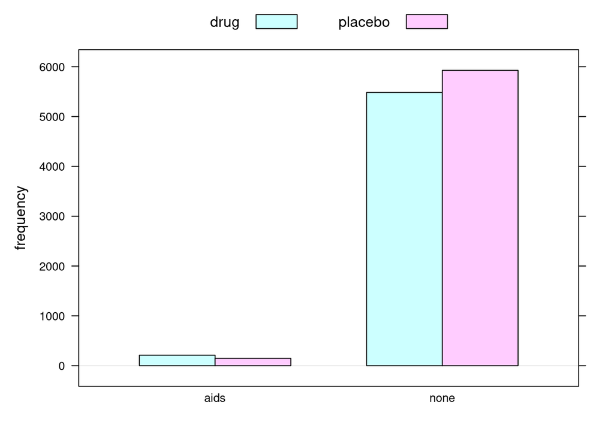

```r
barchartGC(~infected + treatment,data=WomanData)
```

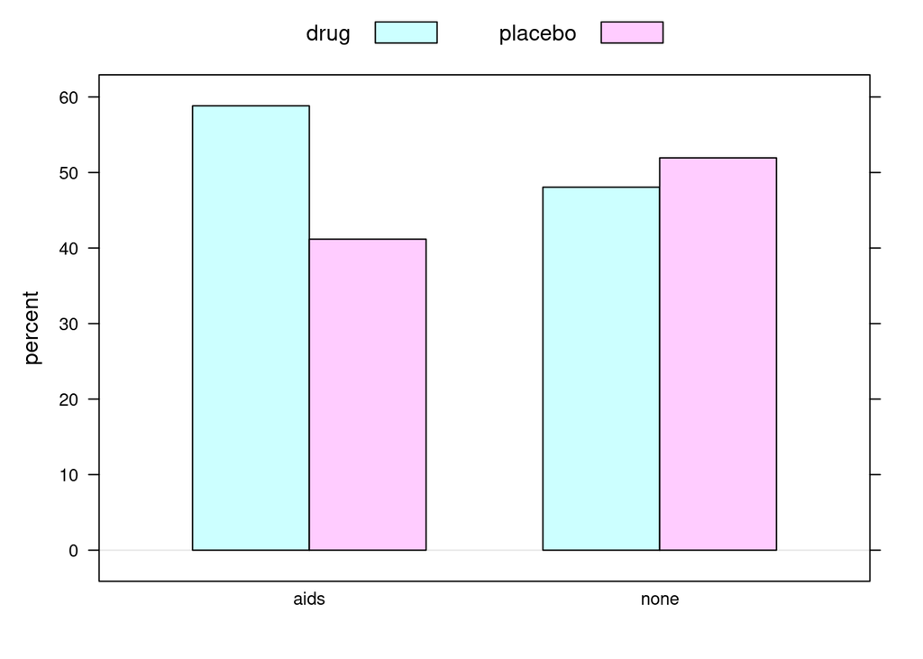

```r
barchartGC(~infected + treatment,data=WomanData, type="percent")
```

```r
dd2 <- WomanData %>% group_by(infected,treatment) %>% summarize(count=n()) %>% mutate(prcnt=count/sum(count))
```

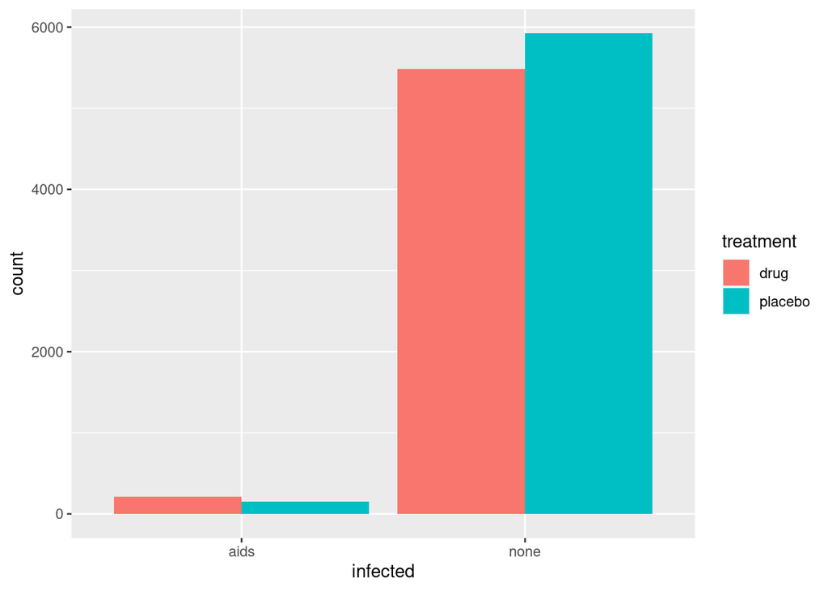

```r
# the group_by followed by summarize(count=n())

basicC <- ggplot(dd2,aes(x=infected,y=count,fill=treatment))
basicC + geom_bar(stat="identity",position="dodge")
```

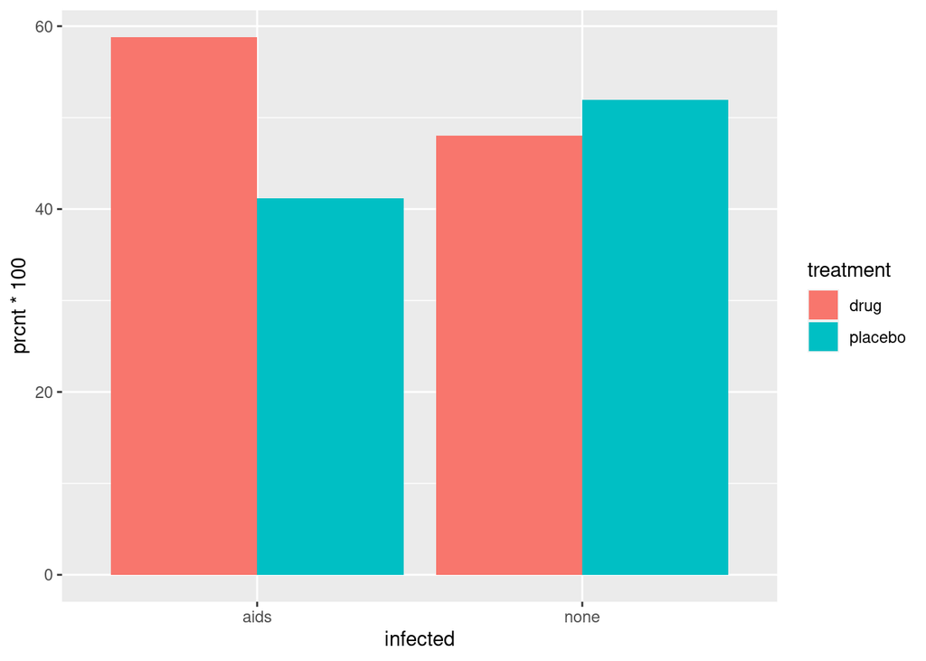

```r
#Now for percentage plot

basicCC <- ggplot(dd2,aes(x=infected,y=prcnt*100,fill=treatment))
basicCC + geom_bar(stat="identity", position = "dodge")
```

The women beforehand getting the vaccine are more prone to aids than those getting the placebo or not getitng the vaccine.

### Numerical Descriptive Results

```r
table1 <- xtabs(~infected + treatment, data=WomanData)
rowPerc(table1)
```

```
##         treatment
## infected   drug placebo  Total
##     aids  58.82   41.18 100.00
##     none  48.06   51.94 100.00
```

```r
colPerc(table1)
```

```
##         treatment
## infected   drug placebo
##    aids    3.69    2.42
##    none   96.31   97.58
##    Total 100.00  100.00
```

This table shows 59% had received the vaccine before had and theycontracted unlike the 41% of women that did not receive it.

## Inferential Results

```r
chisq.test(table1)
```

```
##
##  Pearson's Chi-squared test with Yates' continuity correction
##
## data:  table1
## X-squared = 15.634, df = 1, p-value = 7.686e-05
```

```r
chisqtestGC(table1)
```

```
## Pearson's Chi-squared test with Yates' continuity correction
##
## Observed Counts:
##         treatment
## infected drug placebo
##     aids  210     147
##     none 5484    5927
##
## Counts Expected by Null:
##         treatment
## infected    drug placebo
##     aids  172.74  184.26
##     none 5521.26 5889.74
##
## Contributions to the chi-square statistic:
##         treatment
## infected drug placebo
##     aids 8.04    7.54
##     none 0.25    0.24
##
##
## Chi-Square Statistic = 15.6339
## Degrees of Freedom of the table = 1
## P-Value = 1e-04
```

```r
fisher.test(table1)
```

```
##
##  Fisher's Exact Test for Count Data
##
## data:  table1
## p-value = 6.596e-05
## alternative hypothesis: true odds ratio is not equal to 1
## 95 percent confidence interval:
##  1.240408 1.925729
## sample estimates:
## odds ratio
##   1.543902
```

3 sets of test that were run and the sets p value were too small that I have to rejectthe null hypothesis that’s its impossible to recreate . The odds ratio 1.5439 are more women who are likely that women to get aid compared to those who did not .

# Discussion and Conclusion

According to the ratio odds there is only a 1.543901 :1 of women contracting aids after getting the vaccine, unlike those women who got placebo effect .The p value set are too low that the null hypothesis is rejected because the confidence ratio is entirely above one meaning it does not work .It does not protect, it does the opposite it increase the chances for aids .